# Premier League Analysis Portfolio

# Win-Draw-Loss Patterns for Liverpool FC

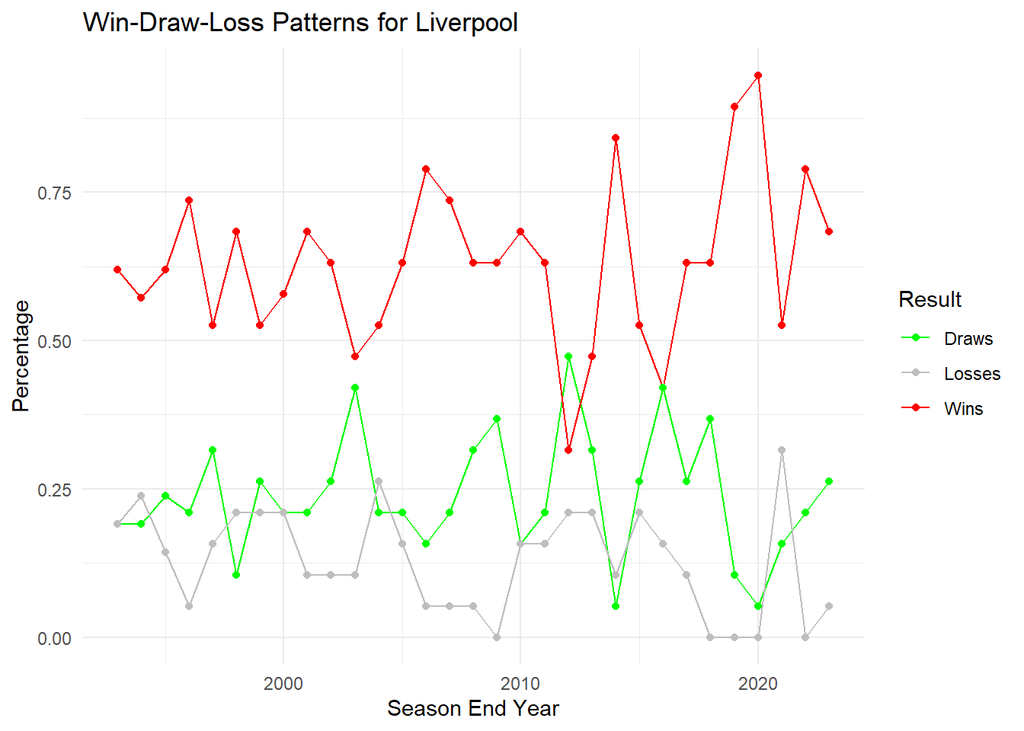

```r
# Calculate win, draw, loss percentages for each team
team_results <- pl_subset %>%
  mutate(Result = case_when(
    HomeGoals > AwayGoals ~ "Win",
    HomeGoals < AwayGoals ~ "Loss",
    TRUE ~ "Draw"
  )) %>%
  group_by(Season_End_Year, Team = Home) %>%
  summarise(
    Wins = sum(Result == "Win") / n(),
    Draws = sum(Result == "Draw") / n(),
    Losses = sum(Result == "Loss") / n()
  )
team <- "Liverpool"  # Replace with the team you want to analyze
team_results_filtered <- team_results %>%
  filter(Team == team) %>%
  pivot_longer(cols = c(Wins, Draws, Losses), names_to = "Result", values_to = "Percentage")

ggplot(team_results_filtered, aes(x = Season_End_Year, y = Percentage, color = Result)) +
  geom_line() +
  geom_point() +
  labs(x = "Season End Year", y = "Percentage", color = "Result", title = paste("Win-Draw-Loss Patterns for", team)) +
  scale_color_manual(values = c("green", "gray", "red")) +
  theme_minimal()
```

# Goal Scoring Trends for Liverpool FC

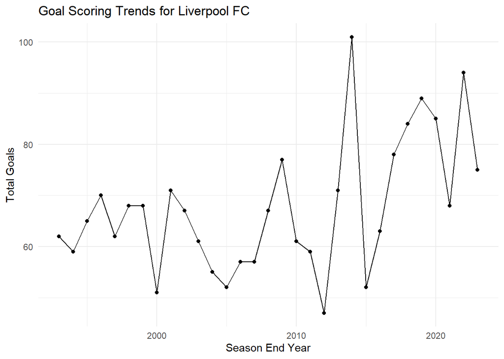

```r
# Calculate total goals scored by Liverpool FC per season
goals_liverpool <- pl_subset %>%
  filter(Home == "Liverpool" | Away == "Liverpool") %>%
  group_by(Season_End_Year) %>%
  summarise(TotalGoals = sum(HomeGoals[Home == "Liverpool"]) + sum(AwayGoals[Away == "Liverpool"]))

# Plotting goal scoring trends for Liverpool FC
ggplot(goals_liverpool, aes(x = Season_End_Year, y = TotalGoals)) +
  geom_line() +
  geom_point() +
  labs(x = "Season End Year", y = "Total Goals", title = "Goal Scoring Trends for Liverpool FC") +
  theme_minimal()
```

# Distribution of Goals Scored by Liverpool FC

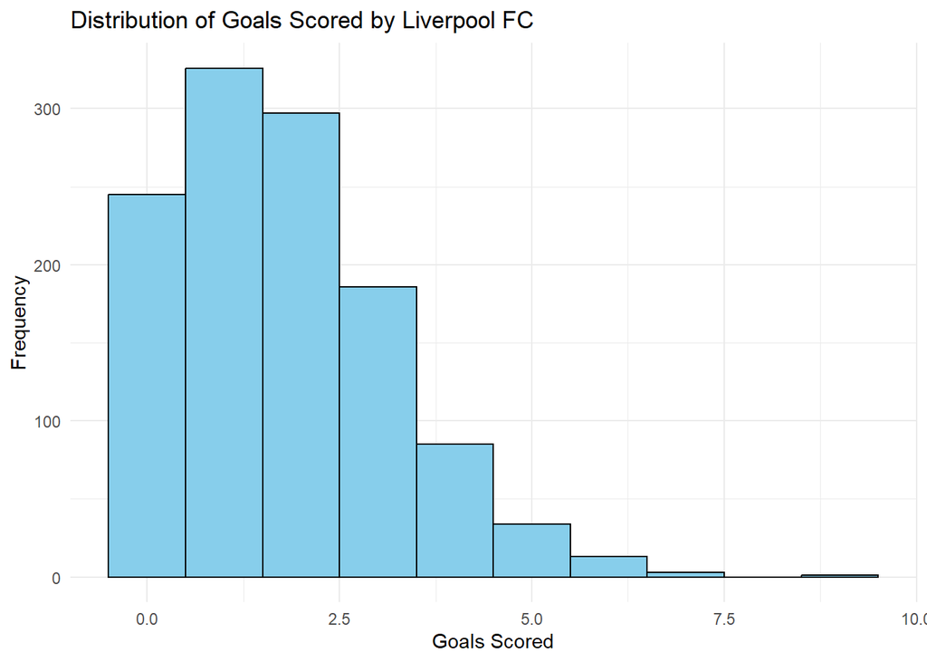

```r
# Filter data for matches involving Liverpool FC
liverpool_goals <- pl_subset %>%
  filter(Home == "Liverpool" | Away == "Liverpool") %>%
  mutate(TotalGoals = ifelse(Home == "Liverpool", HomeGoals, AwayGoals))

# Plotting distribution of goals scored by Liverpool FC
ggplot(liverpool_goals, aes(x = TotalGoals)) +
  geom_histogram(binwidth = 1, fill = "skyblue", color = "black") +
  labs(x = "Goals Scored", y = "Frequency", title = "Distribution of Goals Scored by Liverpool FC") +
  theme_minimal()
```

# Home and Away Performances of Liverpool FC

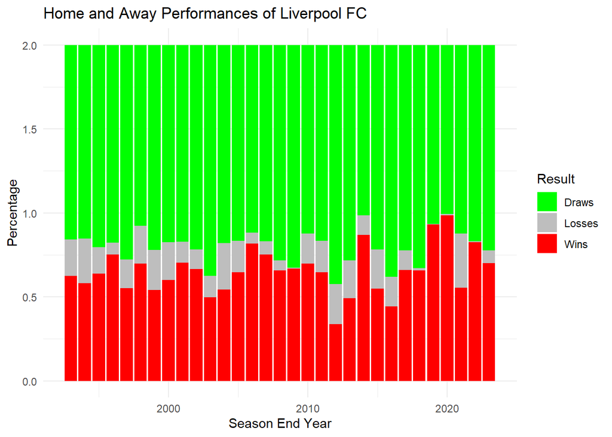

```r
# Calculate home and away performance metrics for Liverpool FC
home_away_performance <- pl_subset %>%
  mutate(Result = case_when(
    Home == "Liverpool" & HomeGoals > AwayGoals ~ "Win",
    Away == "Liverpool" & AwayGoals > HomeGoals ~ "Win",
    Home == "Liverpool" & HomeGoals < AwayGoals ~ "Loss",
    Away == "Liverpool" & AwayGoals < HomeGoals ~ "Loss",
    TRUE ~ "Draw"
  )) %>%
  group_by(Season_End_Year, Venue = ifelse(Home == "Liverpool", "Home", "Away")) %>%
  summarise(
    Wins = sum(Result == "Win") / n(),
    Draws = sum(Result == "Draw") / n(),
    Losses = sum(Result == "Loss") / n()
  )
# Reshape data for stacked bar chart
home_away_performance_long <- home_away_performance %>%
  pivot_longer(cols = c(Wins, Draws, Losses), names_to = "Result", values_to = "Percentage")

# Plotting home and away performances of Liverpool FC (stacked bar chart)
ggplot(home_away_performance_long, aes(x = Season_End_Year, y = Percentage, fill = Result)) +
  geom_bar(stat = "identity", position = "stack") +
  labs(x = "Season End Year", y = "Percentage", fill = "Result", title = "Home and Away Performances of Liverpool FC") +
  theme_minimal() +
  scale_fill_manual(values = c("green", "gray", "red"))
```

# Predictive Model for Goals Scored by Liverpool FC

```r
# Example: Building a linear regression model to predict goals scored by Liverpool FC

# Combine home and away matches into a single dataset
liverpool_goals <- pl_subset %>%
  mutate(GoalsScored = ifelse(Home == "Liverpool", HomeGoals, AwayGoals),
         Opponent_strength = ifelse(Home == "Liverpool", AwayGoals, HomeGoals))  # Hypothetical opponent strength example

# Build a linear regression model to predict goals scored by Liverpool FC
goal_model <- lm(GoalsScored ~ Opponent_strength + as.factor(Home), data = liverpool_goals)

# Summary of the regression model
summary(goal_model)
```

```
##
## Call:
## lm(formula = GoalsScored ~ Opponent_strength + as.factor(Home),
##     data = liverpool_goals)
##
## Residuals:
##     Min      1Q  Median      3Q     Max
## -2.1562 -1.0179 -0.1382  0.7314  7.7310
##
## Coefficients:
##                                 Estimate Std. Error t value Pr(>|t|)
## (Intercept)                     0.886626   0.049916  17.763  < 2e-16 ***
## Opponent_strength              -0.011220   0.008412  -1.334 0.182302
## as.factor(Home)Aston Villa      0.239851   0.068324   3.511 0.000449 ***
## as.factor(Home)Barnsley         0.970242   0.266726   3.638 0.000276 ***
## as.factor(Home)Birmingham City  0.179672   0.109957   1.634 0.102282
## as.factor(Home)Blackburn        0.225773   0.077315   2.920 0.003505 **
## as.factor(Home)Blackpool        1.078458   0.266685   4.044 5.29e-05 ***
## as.factor(Home)Bolton           0.395071   0.086829   4.550 5.42e-06 ***
## as.factor(Home)Bournemouth      0.672587   0.117114   5.743 9.53e-09 ***
## as.factor(Home)Bradford City    0.653272   0.191575   3.410 0.000652 ***
## as.factor(Home)Brentford        0.156520   0.191503   0.817 0.413760
## as.factor(Home)Brighton         0.407953   0.117171   3.482 0.000500 ***
## as.factor(Home)Burnley          0.408153   0.104308   3.913 9.17e-05 ***
## as.factor(Home)Cardiff City     1.046533   0.191618   5.462 4.81e-08 ***
## as.factor(Home)Charlton Ath     0.430695   0.104165   4.135 3.58e-05 ***
## as.factor(Home)Chelsea         -0.018051   0.066345  -0.272 0.785563
## as.factor(Home)Coventry City    0.251550   0.098191   2.562 0.010424 *
## as.factor(Home)Crystal Palace   0.406990   0.084337   4.826 1.41e-06 ***
## as.factor(Home)Derby County     0.457446   0.109977   4.159 3.21e-05 ***
## as.factor(Home)Everton          0.251297   0.066483   3.780 0.000158 ***
## as.factor(Home)Fulham           0.418017   0.080867   5.169 2.39e-07 ***
## as.factor(Home)Huddersfield     0.594735   0.191785   3.101 0.001933 **
## as.factor(Home)Hull City        0.652327   0.126646   5.151 2.64e-07 ***
## as.factor(Home)Ipswich Town     0.384686   0.123318   3.119 0.001816 **
## as.factor(Home)Leeds United     0.253665   0.081981   3.094 0.001978 **
## as.factor(Home)Leicester City   0.409186   0.079094   5.173 2.34e-07 ***
## as.factor(Home)Liverpool        1.142499   0.067140  17.017  < 2e-16 ***
## as.factor(Home)Manchester City  0.086195   0.069418   1.242 0.214374
## as.factor(Home)Manchester Utd  -0.126920   0.066341  -1.913 0.055752 .
```

[output cut: 13 more lines]

```
## as.factor(Home)Swansea City     0.406670   0.109896   3.701 0.000216 ***
## as.factor(Home)Swindon Town     1.269588   0.254153   4.995 5.96e-07 ***
## as.factor(Home)Tottenham        0.213507   0.066384   3.216 0.001302 **
## as.factor(Home)Watford          0.679292   0.104231   6.517 7.45e-11 ***
## as.factor(Home)West Brom        0.588313   0.086891   6.771 1.34e-11 ***
## as.factor(Home)West Ham         0.404442   0.068959   5.865 4.61e-09 ***
## as.factor(Home)Wigan Athletic   0.540323   0.104274   5.182 2.23e-07 ***
## as.factor(Home)Wimbledon        0.382019   0.102549   3.725 0.000196 ***
## as.factor(Home)Wolves           0.530006   0.099543   5.324 1.03e-07 ***
## ---
## Signif. codes:  0 '***' 0.001 '**' 0.01 '*' 0.05 '.' 0.1 ' ' 1
##
## Residual standard error: 1.144 on 11975 degrees of freedom
## Multiple R-squared:  0.05495,    Adjusted R-squared:  0.05101
## F-statistic: 13.93 on 50 and 11975 DF,  p-value: < 2.2e-16
```

```r
# Predicting goals scored by Liverpool FC
# Example prediction:
new_data <- data.frame(Opponent_strength = 1.5, Home = "Liverpool")  # Adjust opponent strength and match location as per data
predicted_goals <- predict(goal_model, newdata = new_data)
predicted_goals
```

```
##        1
## 2.012295
```

# Interpretation of Predictive Model Results

The results from the linear regression model provide valuable insights into predicting goals scored by Liverpool FC in the Premier League. The analysis reveals several key findings. Firstly, the coefficient for `Opponent_strength` suggests that while there is a slight negative trend (-0.0112), indicating that stronger opponents may marginally reduce Liverpool’s expected goals, this relationship is not statistically significant (p-value = 0.182). This implies that opponent strength alone may not strongly influence Liverpool’s goal-scoring performance.

As an example, for a hypothetical scenario where the opponent’s strength is 1.5 and Liverpool plays at home, the model predicts they will score approximately 2.01 goals. This prediction showcases the model’s application in forecasting goal-scoring scenarios based on the specified variables.

In conclusion, while the model provides valuable insights into predicting Liverpool’s goal-scoring performance, it underscores the complexity of football dynamics and the multitude of factors influencing match outcomes. Future analyses could explore additional variables to enhance predictive accuracy and further refine understanding of team performance in football.

# Conclusion